# Part II - (Prosper Loan Dataset)

## by (Ibukun Racheal Olaseile)

## Investigation Overview

> One of my main focus for the project was what determines the outcome of the BorrowerAPR, so I explored some variables e.g the LoanOriginalAmount, ProsperRating and Term. There was a negative correlation between the BorrowerAPR and the LoanOriginalAmont, what this implies is that the more loan you acquire, the lower your APR but interestingly when other factors e.g the Term of loan and ProsperRating are involved, the BorrowerAPR might increase.

## Dataset Overview

> The dataset used in this report is Prosper Loan Data, Prosper is a california based company that issues loan to borrowers at a low interest rate. I will be using the various python libraries (Numpy, Pandas, Matplotlib and seaborn ) for exploration and explanation analysis. The various data visualizations made in this project will help me futher understand my dataset.

## (Visualization 1)

> The major goal for this project is to find out factors that determine the BorrowerAPR, I will exploring the distribution of the BorrowerAPR first.

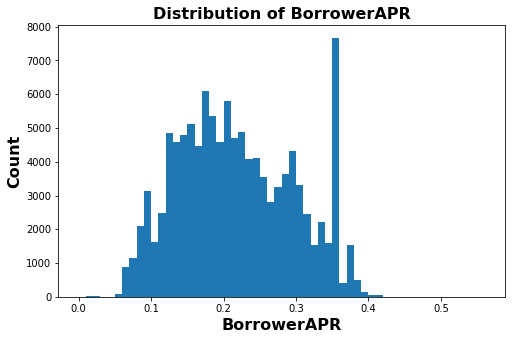

From the chart above, the distribution for the BorrowerAPR is multimodal, ie there are various peaks of the APR with the highest being recorded between 0.35 and 0.36

## (Visualization 2)

> The next exploration is finding out the relationship between the BorrowerAPR and LoanOriginalAmount

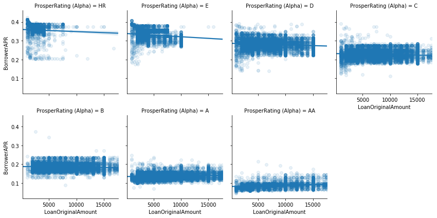

There is a negative correlation between the LoanOriginalAmount and BorrowerAPR, this implies that as the Loan amount increases, the BorrowerAPR decreases.

## (Visualization 3)

My last exploration will be to determine what these variables (Term and ProsperRating) has on the relationship between BorrowerAPR and LoanOriginalAmount

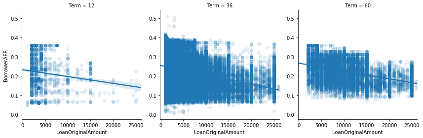

The Loan Term doesnt affect the relationship between the BorrowerAPR and LoanOriginalAmount as the correlation among them remains the same across all terms

# Visualization 4

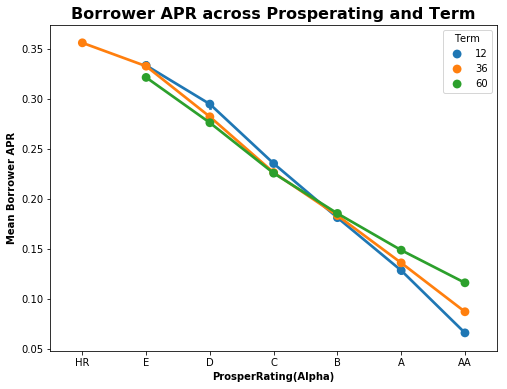

As seen on the last chart, the BorrowerAPR can change depending on the Term or ProsperRating.The BorrowerAPR decreases as the term increases for ProsperRating between (HR-C) while there was an Increament in the BorrowerAPR for ProsperRating (B-AA)